# Add Your Project Title Here

# 5 Model Selection and Justification

TODO: Choose at least **two** statistical models or tests if you work individually, or at least **three** if you work as a pair (e.g., t-test, ANOVA, MANOVA, chi-square test, correlation test, linear or logistic regression, decision tree, random forest, neural network). Fill in the table, then justify each choice in a short paragraph.

Table 4: Models used and their assumptions

[output not shown]

TODO: For each model, explain:

- **Why this model fits your question and data types.** Example: “The outcome is numeric and the predictor has three groups, so a one-way ANOVA compares the group means.”
- **What alternatives you considered** and why you rejected them.
- **What you will do if an assumption fails.** Examples: a nonparametric test such as Wilcoxon or Kruskal-Wallis, a transformation, or a different model.

## 5.1 A method not covered in class (only if you use one)

TODO: If you use a method we did not cover in class, explain it here in your own words. Cover how it works, what its output means, its assumptions, why it suits your data better than the methods from class, and at least one citation `[@key]`. If you only use methods from class, delete this subsection.

# 6 Results

TODO: Make one subsection per hypothesis. In each one, check the model’s assumptions (with a plot or test), fit the model, and report:

- the test statistic, degrees of freedom (if any) and **p-value**;
- a **confidence interval** or another measure of uncertainty;
- an **effect size** or performance metric (e.g., difference in means, Cohen’s d, R², η², odds ratio, accuracy on held-out test data);
- your **decision**: reject H<sub>0</sub> or fail to reject H<sub>0</sub> at α = 0.05; and
- a plain-language sentence that someone without statistics training could understand.

For predictive models (decision trees, neural networks, …), split the data into training and test sets and report performance on the **test** set.

## 6.1 Hypothesis 1

```r
# TODO: Check assumptions, fit the model for Hypothesis 1 and show the results.
```

TODO: Report and interpret the results for Hypothesis 1.

## 6.2 Hypothesis 2

```r
# TODO: Check assumptions, fit the model for Hypothesis 2 and show the results.
```

TODO: Report and interpret the results for Hypothesis 2.

## 6.3 Hypothesis 3 (pairs only)

```r
# TODO: Check assumptions, fit the model for Hypothesis 3 and show the results.
# Delete this subsection if you are working individually.
```

TODO: Report and interpret the results for Hypothesis 3.

## 6.4 Robustness check (pairs only)

TODO: Check whether one main result holds up when you change an analysis choice, for example: a nonparametric test instead of a parametric one, keeping or removing outliers, a different subset of years or groups, or a different model. Report whether the conclusion changes. Delete this subsection if you are working individually.

**NoteEXAMPLE: reporting results (delete this block)**

**Hypothesis 1: Welch two-sample t-test.**

```r
h1 <- t.test(len ~ supp, data = tooth)  # Welch: does not assume equal variances
h1
```

```
    Welch Two Sample t-test

data:  len by supp
t = 1.9153, df = 55.309, p-value = 0.06063
alternative hypothesis: true difference in means between group Orange juice and group Ascorbic acid is not equal to 0
95 percent confidence interval:
 -0.1710156  7.5710156
sample estimates:
 mean in group Orange juice mean in group Ascorbic acid
                   20.66333                    16.96333
```

*Result:* The mean tooth length was 20.7 for orange juice and 17 for ascorbic acid, t(55.3) = 1.92, p = 0.061, 95% CI for the difference [-0.17, 7.57]. Because p > 0.05 and the interval includes 0, we **fail to reject H<sub>0</sub>**. Averaged over all doses, the data do not show a clear difference between the supplements.

**Hypothesis 2: two-way ANOVA with interaction.**

```r
h2 <- aov(len ~ dose * supp, data = tooth)
summary(h2)
```

```
            Df Sum Sq Mean Sq F value   Pr(>F)
dose         2 2426.4  1213.2  92.000  < 2e-16 ***
supp         1  205.4   205.4  15.572 0.000231 ***
dose:supp    2  108.3    54.2   4.107 0.021860 *
Residuals   54  712.1    13.2
---
Signif. codes:  0 '***' 0.001 '**' 0.01 '*' 0.05 '.' 0.1 ' ' 1
```

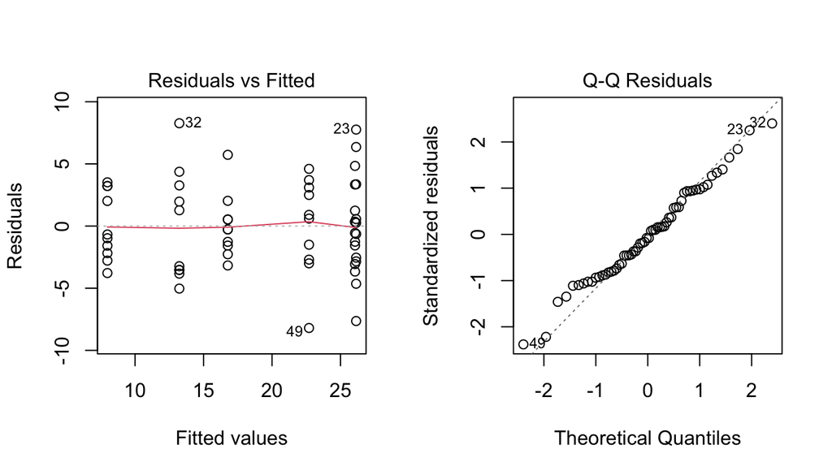

Figure 3: EXAMPLE: Residual diagnostics for the two-way ANOVA.

```r
par(mfrow = c(1, 2))
plot(h2, which = 1:2)  # residuals vs fitted (equal variance), Q-Q (normality)
```

*Result:* Dose, supplement and their interaction are all significant (p < 0.05), so we **reject H<sub>0</sub>**. The residual plots show roughly constant spread and approximately normal residuals, so the ANOVA assumptions are reasonable. Notice that supplement type *is* significant once dose is taken into account, even though the simple t-test in Hypothesis 1 was not. Controlling for another variable can change a conclusion.

# 7 Conclusions

## 7.1 Summary of findings

TODO: Complete the table, then answer your research question directly in one or two paragraphs.

Table 5: Summary of hypothesis tests

[output not shown]

## 7.2 Answer to the research question

TODO: Answer your research question. Relate your findings to the literature you cited in Section 1. Do your results agree with prior work?

## 7.3 Limitations

TODO: Discuss the limitations of your data and methods, such as sample size, missing data, sampling bias, measurement error, failed assumptions, and correlation versus causation. Explain how each one could affect your conclusions.

## 7.4 Future work

TODO: What would you study next, and what data or methods would you need?